# Normal distributions webapp

4 November 2019

## Visualizing two-dimensional normal distributions

Have you ever wondered what a two-dimensional normal distribution might look like?

I know I have!

Now there’s **THE** app that will answer that question. Introducing

[**the two-dimensional normal distribution web app**](https://bettmensch88.shinyapps.io/normal_distribution/)

(or *“ttdndwa”* for short)

## Parameters

It’s got everything!

- two dimensional mean: set the center of your distribution!
- 2x2 covariance matrix: control the correlation of both axes by setting this matrix!
- number of bins: have a direct say in how granular the visuals should be!
- number of samples: tired of having too high/low sampling counts? Now you can directly specify your favourite number!

## Plots

Look at this plot! Just look at it!

[interactive chart not shown]

## Manual

It’s super easy to use. Simply specify the settings shown in the screenshot, and see the sampled frequencies change before your eyes!

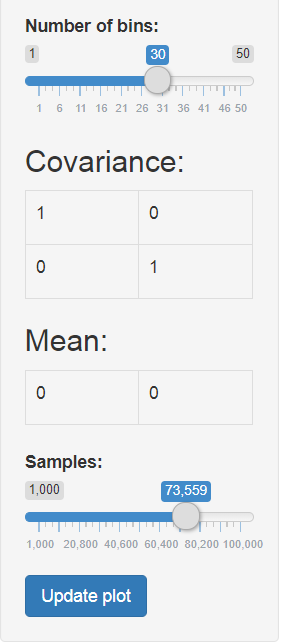

## Summing up

So what are you waiting for?! Visit [ttdndwa](https://bettmensch88.shinyapps.io/normal_distribution/) today and start plotting your own individual two dimensional normal distributions!

Remember:

- it’s quick!
- it’s easy!
- and it’s free!

You’d be *crazy* not to!